# hw05

## Exercise 1: Explain the value of the `here::here` package

The `here::here` package is incredibly useful for writing to and from files. It allows the user to create platform-independent, relative file paths for one’s data, similar to base R’s `file.path` - **but** with an added bonus!. It allows for easy reading and writing of both data and figures to a root directory or to a *subdirectories within the root directory*, thus circumventing the limitations imposed by the classic local working directory in R. Overall, this package is very helpful in aiding one’s own coding process as well as providing a more reliable output for collaboration and reproducability.

## Exercise 2: Factor Management

### Elaboration for the gapminder data set

**Drop Oceania.** Filter the Gapminder data to remove observations associated with the `continent` of Oceania. Additionally, remove unused factor levels. Provide concrete information on the data before and after removing these rows and Oceania; address the number of rows and the levels of the affected factors.

#### Concrete information on the data before removal:

gapminder has 5 levels (one of which being **Oceania**) and 1704 rows.

```r
#does continent contain factors?
class(gapminder$continent)
```

```
## [1] "factor"
```

```r
#what are the levels associated with these factors?
nlevels(gapminder$continent)
```

```
## [1] 5
```

```r
#what are these levels called?
levels(gapminder$continent)
```

```
## [1] "Africa"   "Americas" "Asia"     "Europe"   "Oceania"
```

```r
#how many rows are of these factors are there?
nrow(gapminder)
```

```
## [1] 1704
```

```r
#remove all instances of Oceania from gapminder
dropGap <- gapminder %>%
  filter(continent != 'Oceania') %>%
  droplevels()

#gapminder after dropping Oceania
DT::datatable(dropGap)
```

|  | country | continent | year | lifeExp | pop | gdpPercap |
| --- | --- | --- | --- | --- | --- | --- |
| 1 | Afghanistan | Asia | 1952 | 28.801 | 8425333 | 779.4453145 |
| 2 | Afghanistan | Asia | 1957 | 30.332 | 9240934 | 820.8530296 |
| 3 | Afghanistan | Asia | 1962 | 31.997 | 10267083 | 853.10071 |
| 4 | Afghanistan | Asia | 1967 | 34.02 | 11537966 | 836.1971382 |
| 5 | Afghanistan | Asia | 1972 | 36.088 | 13079460 | 739.9811058 |
| 6 | Afghanistan | Asia | 1977 | 38.438 | 14880372 | 786.11336 |
| 7 | Afghanistan | Asia | 1982 | 39.854 | 12881816 | 978.0114388 |
| 8 | Afghanistan | Asia | 1987 | 40.822 | 13867957 | 852.3959448 |
| 9 | Afghanistan | Asia | 1992 | 41.674 | 16317921 | 649.3413952 |
| 10 | Afghanistan | Asia | 1997 | 41.763 | 22227415 | 635.341351 |

[output cut: 1670 more lines]

```r
#number of levels after dropping Oceania?
nlevels(dropGap$continent)
```

```
## [1] 4
```

```r
#number of rows after dropping Oceania?
nrow(dropGap)
```

```
## [1] 1680
```

**Reorder the levels of `country` or `continent`.** Use the forcats package to change the order of the factor levels, based on summarized information of one of the quantitative variables. Consider experimenting with a summary statistic beyond the most basic choice of the mean/median. Use the `forcats` package in the tidyverse for this, rather than the baseR function `as.factor`.

I will be looking at the minimum life expectancy across each of the continents.

I chose this data to plot because it shows very interesting troughs in Asia for 1977 and Africa in 1992.

These dramatic drops in life expectancy reflect the horrible genocides that occurred in Cambodia and Rwanda respectively during these years in history.

```r
#creation of a new tibble containing the minimum life expectancy in each continent, each year
minLifeGap <- gapminder %>%
  group_by(continent, year) %>%
  mutate(minLife = min(lifeExp)) %>%
  filter(lifeExp == minLife) %>%
  arrange(year, continent)

DT::datatable(minLifeGap)
```

|  | country | continent | year | lifeExp | pop | gdpPercap | minLife |
| --- | --- | --- | --- | --- | --- | --- | --- |
| 1 | Gambia | Africa | 1952 | 30 | 284320 | 485.2306591 | 30 |
| 2 | Haiti | Americas | 1952 | 37.579 | 3201488 | 1840.366939 | 37.579 |
| 3 | Afghanistan | Asia | 1952 | 28.801 | 8425333 | 779.4453145 | 28.801 |
| 4 | Turkey | Europe | 1952 | 43.585 | 22235677 | 1969.10098 | 43.585 |
| 5 | Australia | Oceania | 1952 | 69.12 | 8691212 | 10039.59564 | 69.12 |
| 6 | Sierra Leone | Africa | 1957 | 31.57 | 2295678 | 1004.484437 | 31.57 |
| 7 | Haiti | Americas | 1957 | 40.696 | 3507701 | 1726.887882 | 40.696 |
| 8 | Afghanistan | Asia | 1957 | 30.332 | 9240934 | 820.8530296 | 30.332 |
| 9 | Turkey | Europe | 1957 | 48.079 | 25670939 | 2218.754257 | 48.079 |
| 10 | New Zealand | Oceania | 1957 | 70.26 | 2229407 | 12247.39532 | 70.26 |

[output cut: 50 more lines]

We can change the order of factors to optomize our legend and colour schema using `fct_reorder2()`

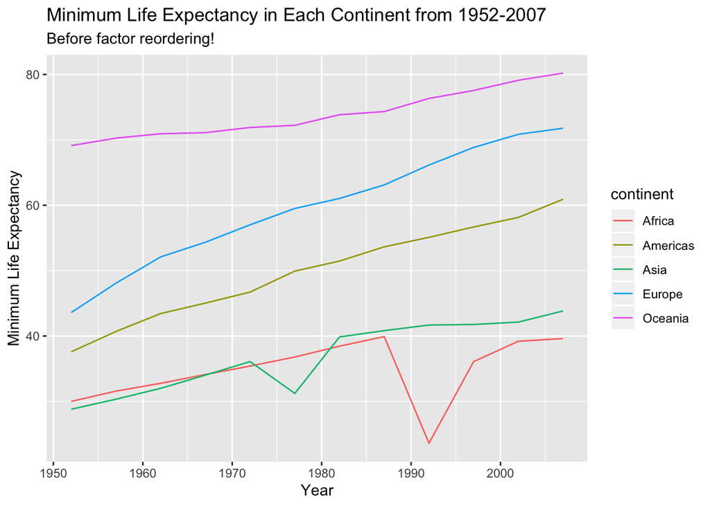

```r
#plot this tibble as is:
minLifeGap %>%
  ggplot(aes(x = year, y = minLife, colour = continent)) +
    geom_line() +
    labs(x = "Year",
         y = "Minimum Life Expectancy",
         title = "Minimum Life Expectancy in Each Continent from 1952-2007",
         subtitle = "Before factor reordering!")
```

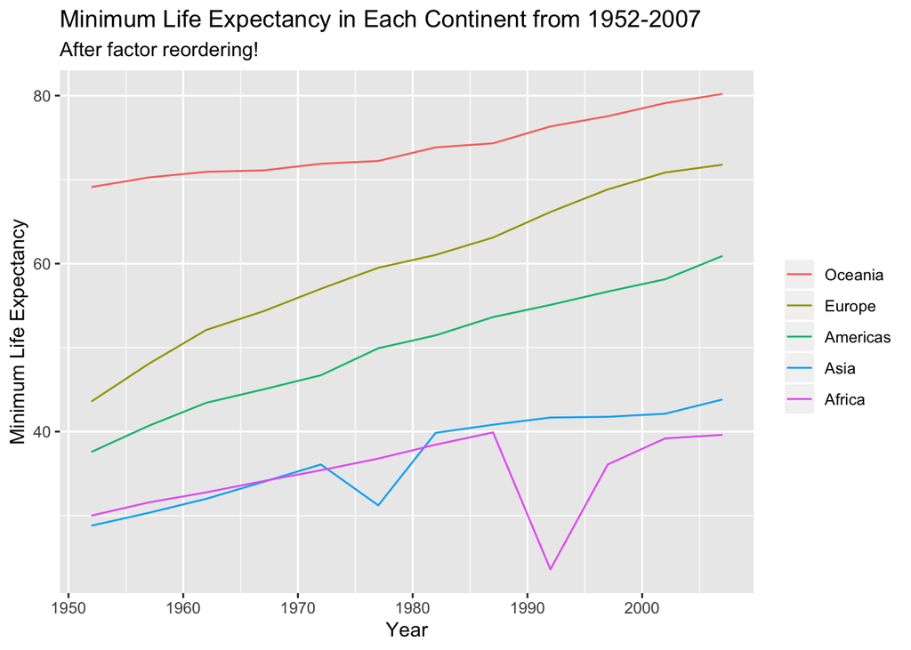

```r
#plot re-ordered tibble:
minLifeGap %>%
  ggplot(aes(x = year, y = minLife,
             colour = fct_reorder2(continent, year, minLife))) +
    geom_line()+
  labs(x = "Year",
         y = "Minimum Life Expectancy",
         title = "Minimum Life Expectancy in Each Continent from 1952-2007",
         subtitle = "After factor reordering!") +
  theme(legend.title = element_blank())
```

We can reorder factors in a scatterplot using `fct_reorder()`

For this plot I used data only from the years *1952* and *2007*.

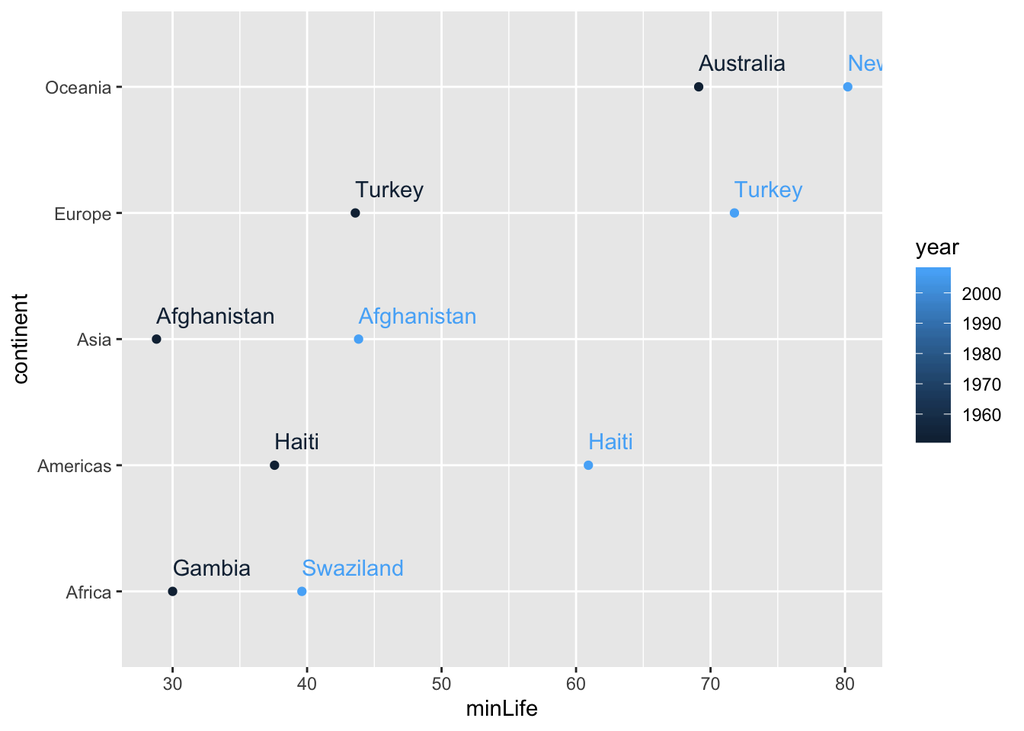

```r
#create new tibble with only 1952 and 2007
minLifeGap_new <- minLifeGap %>%
  filter(year == 1952 | year == 2007) %>%
  arrange(continent)

#before re-ordering
minLifeGap_new %>%
  ggplot(aes(x = minLife, y = continent, colour = year)) +
    geom_point() +
    geom_text(aes(label = country), hjust=0, vjust=-1)
```

[figure not shown]

```r
#after re-ordering
minLifeGap_new %>%
  ggplot(aes(x = minLife, y = fct_reorder(continent, minLife),
             colour = year)) +
    geom_point()+
    geom_text(aes(label = country), hjust=0, vjust=-1)+
  labs(
    x = "Minimum Life Expectancy",
    y = "Continent",
    title = "Minimum Life Expectancy Across the Continents",
    subtitle = "From 1952 and 1957"
  )
```

## Exercise 3: File input/output (I/O)

**Task:** Create something new, export to disk and then reload it. You should use here::here() for reading in and writing out.

**1. CREATE SOMETHING NEW** I will create a version of gapminder containing only the five countries: *Canada, Hungary, Iran, Japan, and Ireland*, their populations, and GDP percapita.

```r
#create new gapminder
gap5 <- gapminder %>%
  filter(country == 'Canada' | country == 'Hungary' | country == 'Iran' |
           country == 'Japan' | country == 'Ireland') %>%
  select(country, year, gdpPercap, pop) %>%
  arrange(country, year, pop, gdpPercap)

DT::datatable(gap5)
```

|  | country | year | gdpPercap | pop |
| --- | --- | --- | --- | --- |
| 1 | Canada | 1952 | 11367.16112 | 14785584 |
| 2 | Canada | 1957 | 12489.95006 | 17010154 |
| 3 | Canada | 1962 | 13462.48555 | 18985849 |
| 4 | Canada | 1967 | 16076.58803 | 20819767 |
| 5 | Canada | 1972 | 18970.57086 | 22284500 |
| 6 | Canada | 1977 | 22090.88306 | 23796400 |
| 7 | Canada | 1982 | 22898.79214 | 25201900 |
| 8 | Canada | 1987 | 26626.51503 | 26549700 |
| 9 | Canada | 1992 | 26342.88426 | 28523502 |
| 10 | Canada | 1997 | 28954.92589 | 30305843 |

[output cut: 50 more lines]

**1. Write to disk and then read back**

```r
#write
write_csv(gap5,here::here("myGapminder.csv"))

#read
read_csv(here::here("myGapminder.csv")) %>%
  DT::datatable()
```

|  | country | year | gdpPercap | pop |
| --- | --- | --- | --- | --- |
| 1 | Canada | 1952 | 11367.16112 | 14785584 |
| 2 | Canada | 1957 | 12489.95006 | 17010154 |
| 3 | Canada | 1962 | 13462.48555 | 18985849 |
| 4 | Canada | 1967 | 16076.58803 | 20819767 |
| 5 | Canada | 1972 | 18970.57086 | 22284500 |
| 6 | Canada | 1977 | 22090.88306 | 23796400 |
| 7 | Canada | 1982 | 22898.79214 | 25201900 |
| 8 | Canada | 1987 | 26626.51503 | 26549700 |
| 9 | Canada | 1992 | 26342.88426 | 28523502 |
| 10 | Canada | 1997 | 28954.92589 | 30305843 |

[output cut: 50 more lines]

## Exercise 4: Visualization design

**Task:** Recreate at least one figure in light of something you learned in the recent class meetings about visualization design and color.

Create a side-by-side plot and juxtapose your first attempt (show the original figure as-is) with a revised attempt after some time spent working on it and implementing principles of effective plotting principles. Comment and reflect on the differences.

##### I chose a figure that I made from hw03 task option #2

Here is the original figure looking at the maximum and minimum GDP percapita in each of the continents over all of the years in gapminder.

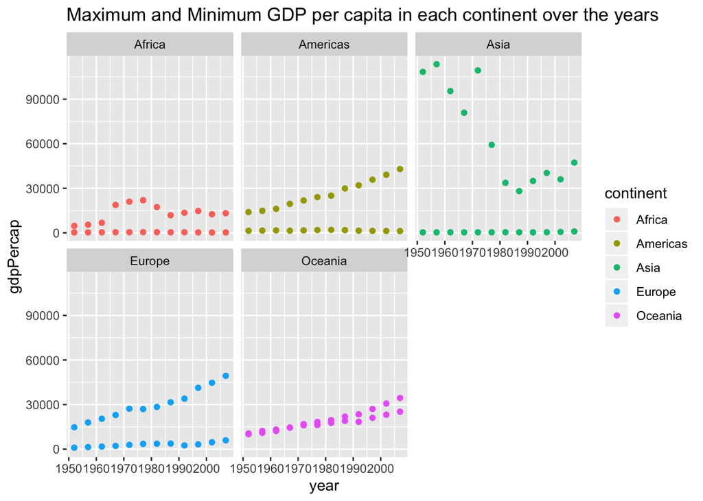

```r
#tibble data for old plot
gdpCont <- gapminder %>%
            group_by(year, continent) %>%
            arrange(year, continent) %>%
            mutate(maximum = max(gdpPercap), minimum = min(gdpPercap)) %>%
            filter(gdpPercap == maximum | gdpPercap == minimum) %>%
            select(year, continent, gdpPercap)
#original plot
myOldPlot<- ggplot(gdpCont, aes(year, gdpPercap, colour = continent)) +
  geom_point() +
  facet_wrap(~ continent) +
  labs(
    title = "Maximum and Minimum GDP per capita in each continent over the years"
  )
myOldPlot
```

New cleaned up version :)

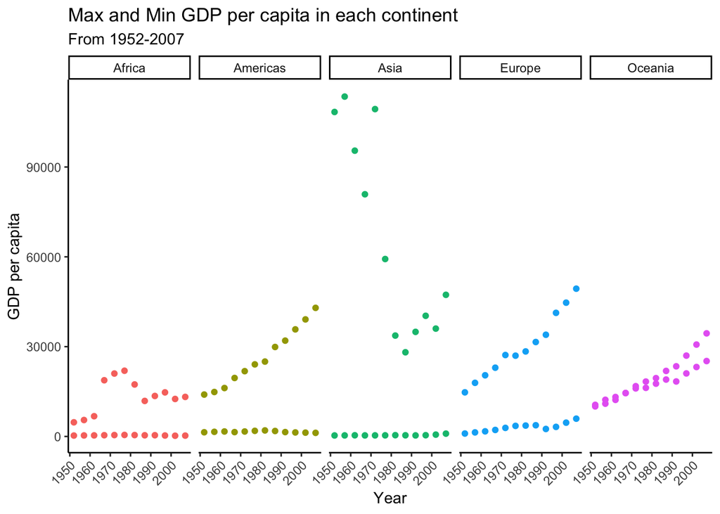

```r
#new clean plot
myNewPlot <- ggplot(gdpCont, aes(year, gdpPercap, colour = continent)) +
  geom_point() +
  facet_wrap(~ continent, nrow = 1) +
  labs(
    x = "Year",
    y = "GDP per capita",
    title = "Max and Min GDP per capita in each continent",
    subtitle = "From 1952-2007"
  )+
  theme_classic()+
  theme(legend.position = "none",
        axis.text.x = element_text(angle = 45,
                                   hjust = 1,
                                   vjust = 1))
myNewPlot
```

## Exercise 5: Writing figures to file

**Task:** Use `ggsave()` to explicitly save a plot to file. Include the exported plot as part of your repository and assignment.

Then, use `![Alt text](/path/to/img.png)` to load and embed that file into your report.

```r
#save previous plot
ggsave(here::here("myNewPlot.png"), plot = myNewPlot)
```

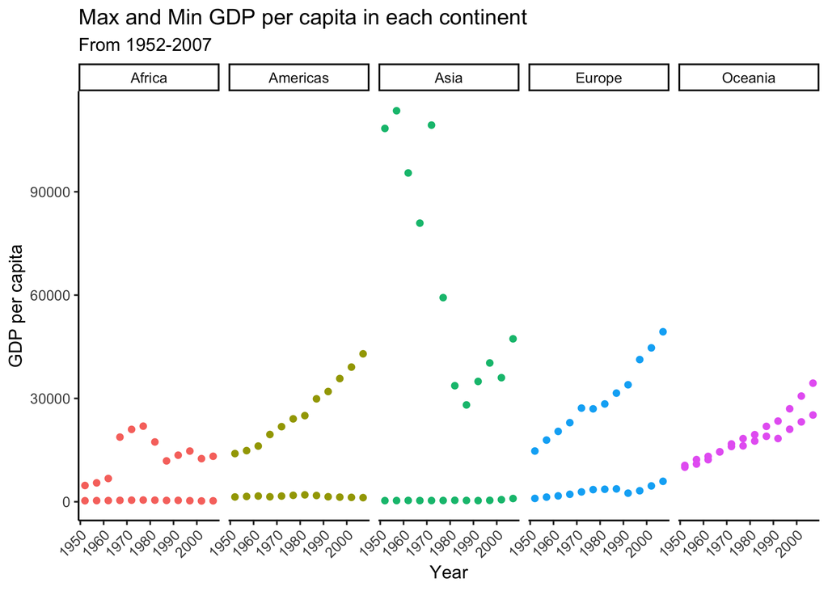